# Proyecto SNV1

Alejandro Brenes, Santiago Fernández, Eyeri Méndez y Erick Venegas

2025-07-08

# Introducción

Se cargan las librerías necesarias.

```r
# Si no funciona descargar caret, usen lo siguiente:

# options(repos = c(CRAN = "https://cloud.r-project.org"))
# remove.packages(c("future", "future.apply", "parallelly", "recipes"))
# install.packages(c("parallelly", "future", "future.apply", "recipes", "caret"), type = "binary")
pacman::p_load(ggplot2,
               readxl,
               cowplot,
               dplyr,
               tidyr,
               corrplot,
               future.apply,
               caret,
               xgboost,
               randomForest,
               tidyverse,
               pROC,
               yardstick,
               pROC)
```

[output not shown]

[output not shown]

[output not shown]

Se lee la base de incendios forestales en Argelia.

```r
# Bases de datos
incendios.B <- read_excel("data/Incendios.xlsx", sheet = "Bejaia")
incendios.SB <- read_excel("data/Incendios.xlsx", sheet = "Sidi-Bel")

# Se juntan las bases
incendios <- rbind(incendios.B, incendios.SB)

# Se cambia el nombre de las categorías de la variable Classes
incendios$Classes <- factor(
  incendios$Classes,
  levels = c("not fire", "fire"),
  labels = c("Sin incendio", "Con incendio")
)

# Se elimina una observación incoherente
incendios <- incendios[-166, ]

# Se transforman las columnas afectadas a tipo numérico
incendios$DC <- round(as.numeric(incendios$DC), 1)
incendios$FWI <- round(as.numeric(incendios$FWI), 1)
```

# Resumen descriptivo y análisis de correlación

Como primer paso, se calculan algunas estadísticas descriptivas tanto para cuando ocurrió un incendio como para cuando no.

```r
dias.con.incendios <- subset(incendios, Classes == "Con incendio")
dias.con.incendios <- dias.con.incendios[, -14]

dias.sin.incendios <- subset(incendios, Classes == "Sin incendio")
dias.sin.incendios <- dias.sin.incendios[, -14]
```

```r
incendios.pivot <- dias.con.incendios %>%
  pivot_longer(cols = everything(),
               names_to = "variable",
               values_to = "valor")

resumen.incendios <- incendios.pivot %>%
  group_by(variable) %>%
  summarise(
    promedio = mean(valor, na.rm = TRUE),
    minimo = min(valor, na.rm = TRUE),
    mediana = median(valor, na.rm = TRUE),
    maximo = max(valor, na.rm = TRUE),
    desviacion = sd(valor, na.rm = TRUE)
  )
```

```r
sin.incendios.pivot <- dias.sin.incendios %>%
  pivot_longer(cols = everything(),
               names_to = "variable",
               values_to = "valor")

resumen.sin.incendios <- sin.incendios.pivot %>%
  group_by(variable) %>%
  summarise(
    promedio = mean(valor, na.rm = TRUE),
    minimo = min(valor, na.rm = TRUE),
    mediana = median(valor, na.rm = TRUE),
    maximo = max(valor, na.rm = TRUE),
    desviacion = sd(valor, na.rm = TRUE)
  )
```

Posteriormente, se realizan gráficos de correlaciones tanta cuando hubo incendio como para cuando no.

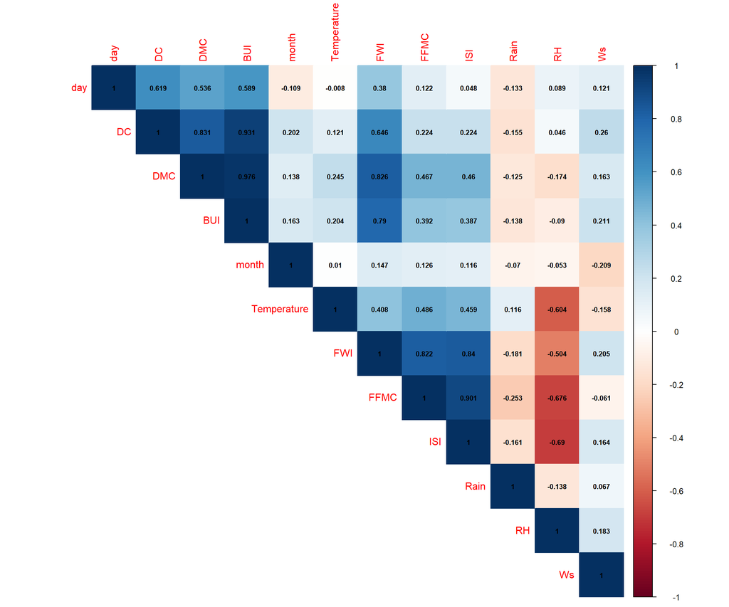

```r
# Correlación de los dias con incendios
cor.incendios <- cor(dias.con.incendios[, apply(dias.con.incendios, 2, var, na.rm = TRUE) != 0], dias.con.incendios[, apply(dias.con.incendios, 2, var, na.rm = TRUE) != 0]) # Solo valores con varianza mayor a 0

corrplot(
  cor.incendios,
  method = "color",
  type = "upper",
  order = "hclust",
  addCoef.col = "black",
  number.cex = 0.7,
  number.digits = 3
)
```

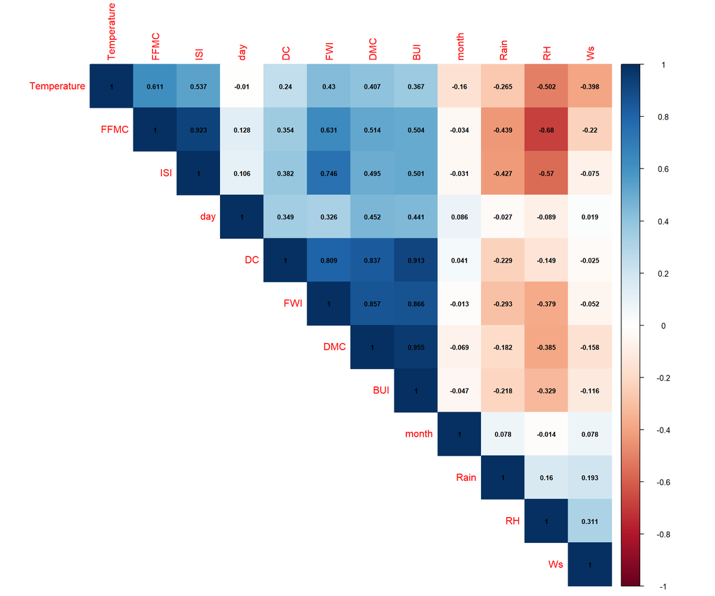

```r
# Correlación de los dias sin incendios
cor.sin.incendios <- cor(dias.sin.incendios[, apply(dias.sin.incendios, 2, var, na.rm = TRUE) != 0], dias.sin.incendios[, apply(dias.sin.incendios, 2, var, na.rm = TRUE) != 0]) # Solo valores con varianza mayor a 0

corrplot(
  cor.sin.incendios,
  method = "color",
  type = "upper",
  order = "hclust",
  addCoef.col = "black",
  number.cex = 0.7,
  number.digits = 3
)
```

Ahora las correlaciones sin incluir las fecha

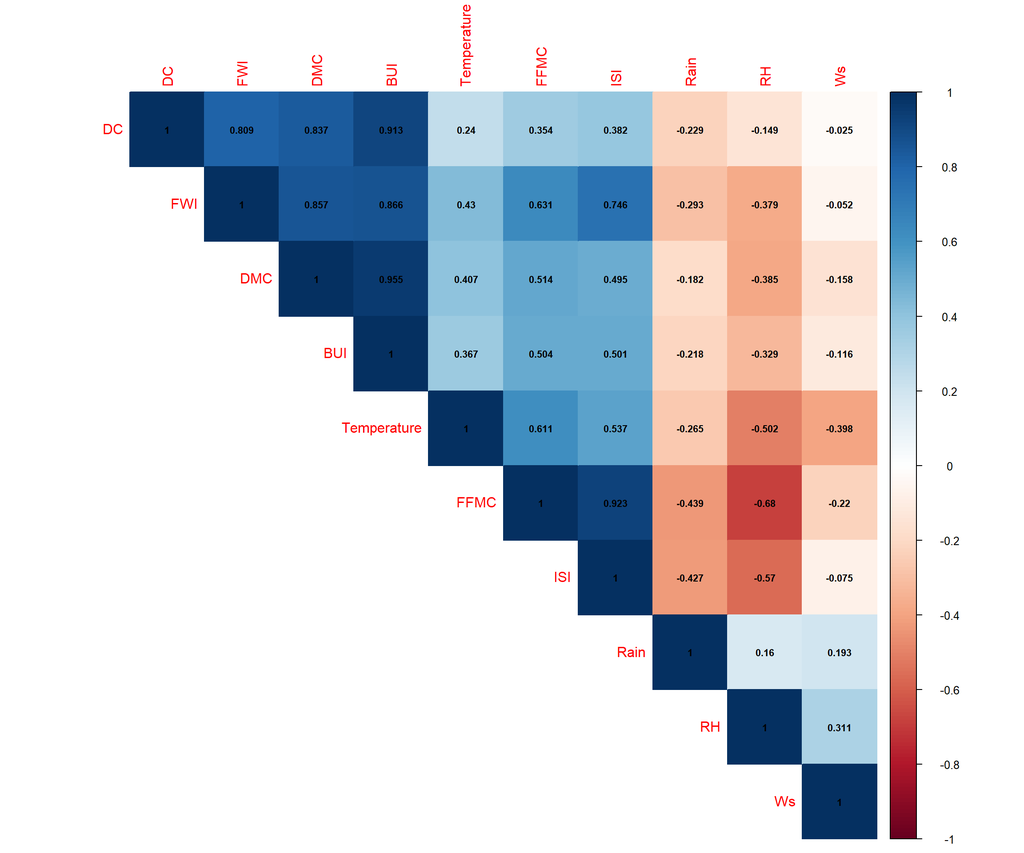

```r
dias.con.incendios.nf <- dias.con.incendios[, -c(1,2,3)]
dias.sin.incendios.nf <- dias.sin.incendios[, -c(1,2,3)]


cor.sin.incendios.nf <- cor(dias.sin.incendios.nf[, apply(dias.sin.incendios.nf, 2, var, na.rm = TRUE) != 0], dias.sin.incendios.nf[, apply(dias.sin.incendios.nf, 2, var, na.rm = TRUE) != 0]) # Solo valores con varianza mayor a 0

corrplot(
  cor.sin.incendios.nf,
  method = "color",
  type = "upper",
  order = "hclust",
  addCoef.col = "black",
  number.cex = 0.7,
  number.digits = 3
)
```

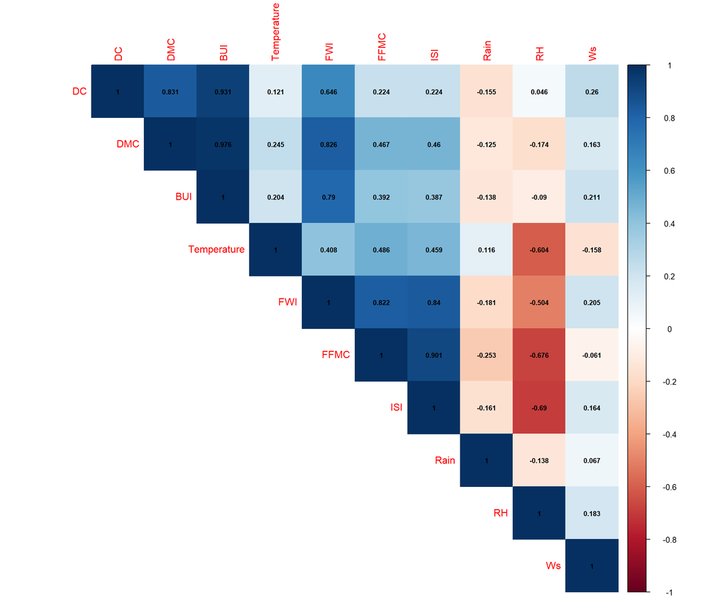

```r
cor.con.incendios.nf <- cor(dias.con.incendios.nf[, apply(dias.con.incendios.nf, 2, var, na.rm = TRUE) != 0], dias.con.incendios.nf[, apply(dias.con.incendios.nf, 2, var, na.rm = TRUE) != 0]) # Solo valores con varianza mayor a 0

corrplot(
  cor.con.incendios.nf,
  method = "color",
  type = "upper",
  order = "hclust",
  addCoef.col = "black",
  number.cex = 0.7,
  number.digits = 3
)
```

# Gráficos entre variables

Se procede a realizar distintos gráficos entre los valores de las variables presentes en la base. Paara esto, se usa como referencia el apartado anterior, graficando solo variables que tengan una correlación mayor a 0.5 (con algunas excepciones).

## Variables vs. FFMC

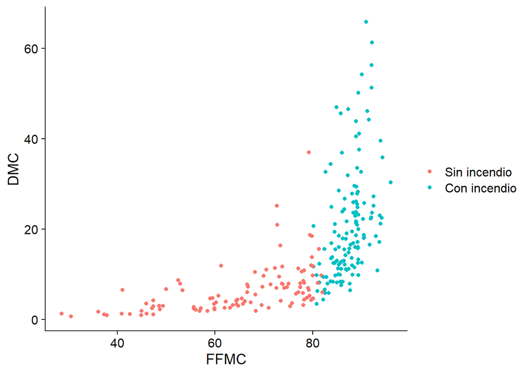

```r
# DMC vs. FFMMC
ggplot(incendios, aes(x = FFMC, y = DMC, color = Classes)) +
  geom_point() +
  labs(x = "FFMC",
       y = "DMC",
       color = "") +
  theme_cowplot()
```

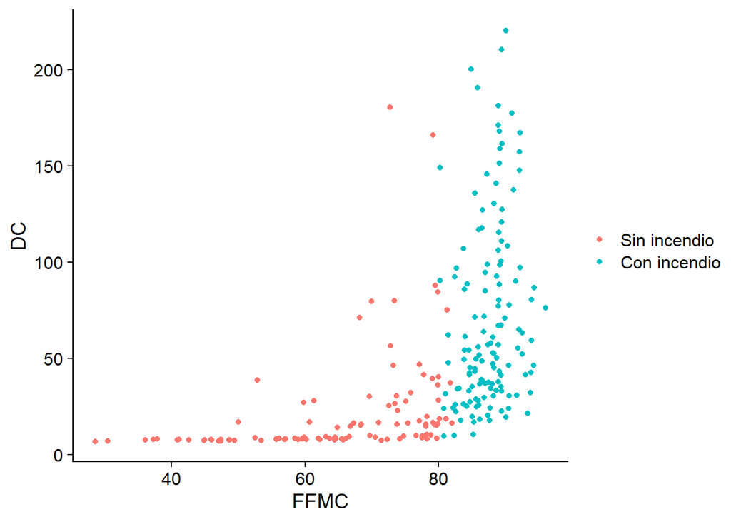

```r
# DC vs. FFMMC
ggplot(incendios, aes(x = FFMC, y = DC, color = Classes)) +
  geom_point() +
  labs(x = "FFMC",
       y = "DC",
       color = "") +
  theme_cowplot()
```

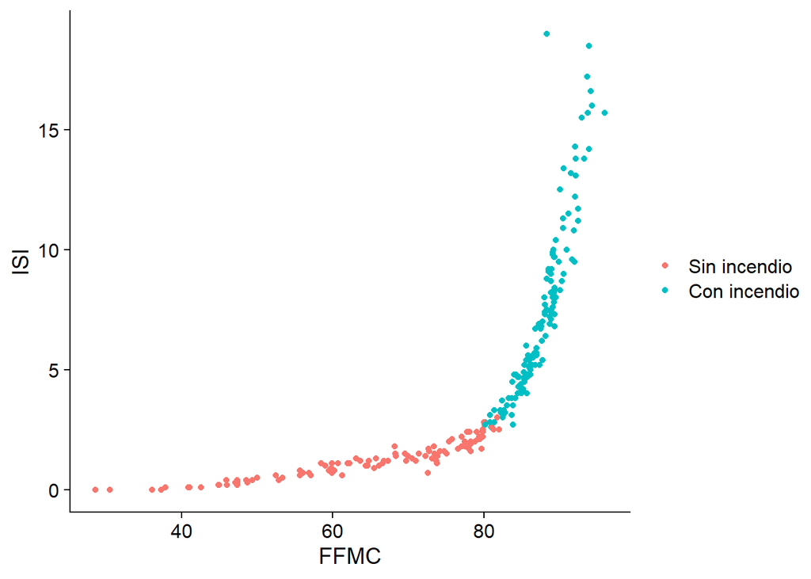

```r
# ISI vs. FFMMC
ggplot(incendios, aes(x = FFMC, y = ISI, color = Classes)) +
  geom_point() +
  labs(x = "FFMC",
       y = "ISI",
       color = "") +
  theme_cowplot()
```

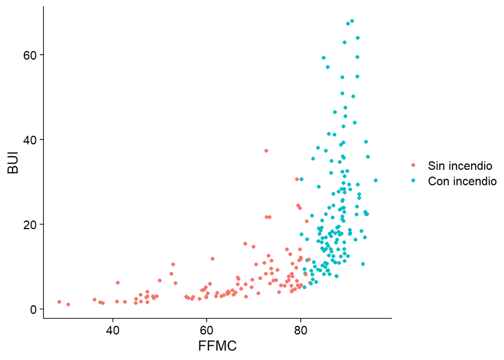

```r
# BUI vs. FFMMC
ggplot(incendios, aes(x = FFMC, y = BUI, color = Classes)) +
  geom_point() +
  labs(x = "FFMC",
       y = "BUI",
       color = "") +
  theme_cowplot()
```

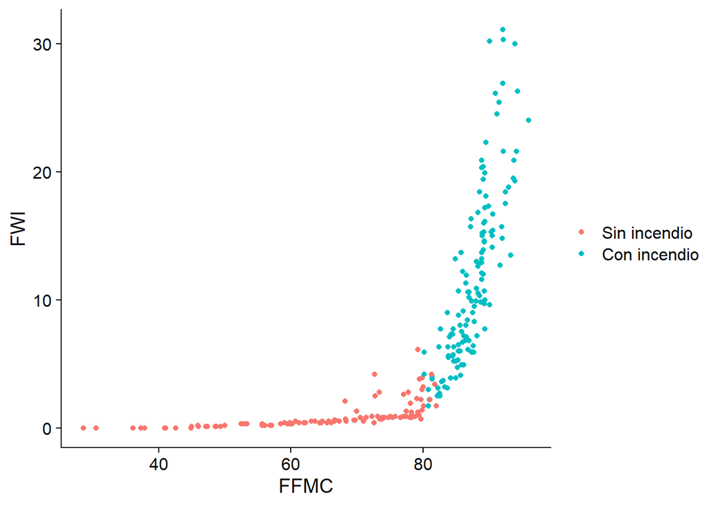

```r
# FWI vs. FFMMC
ggplot(incendios, aes(x = FFMC, y = FWI, color = Classes)) +
  geom_point() +
  labs(x = "FFMC",
       y = "FWI",
       color = "") +
  theme_cowplot()
```

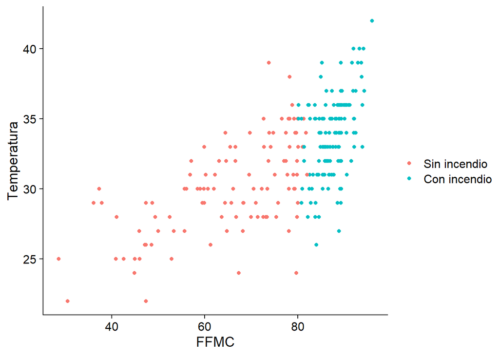

```r
# Temperatura vs. FFMMC
ggplot(incendios, aes(x = FFMC, y = Temperature, color = Classes)) +
  geom_point() +
  labs(x = "FFMC",
       y = "Temperatura",
       color = "") +
  theme_cowplot()
```

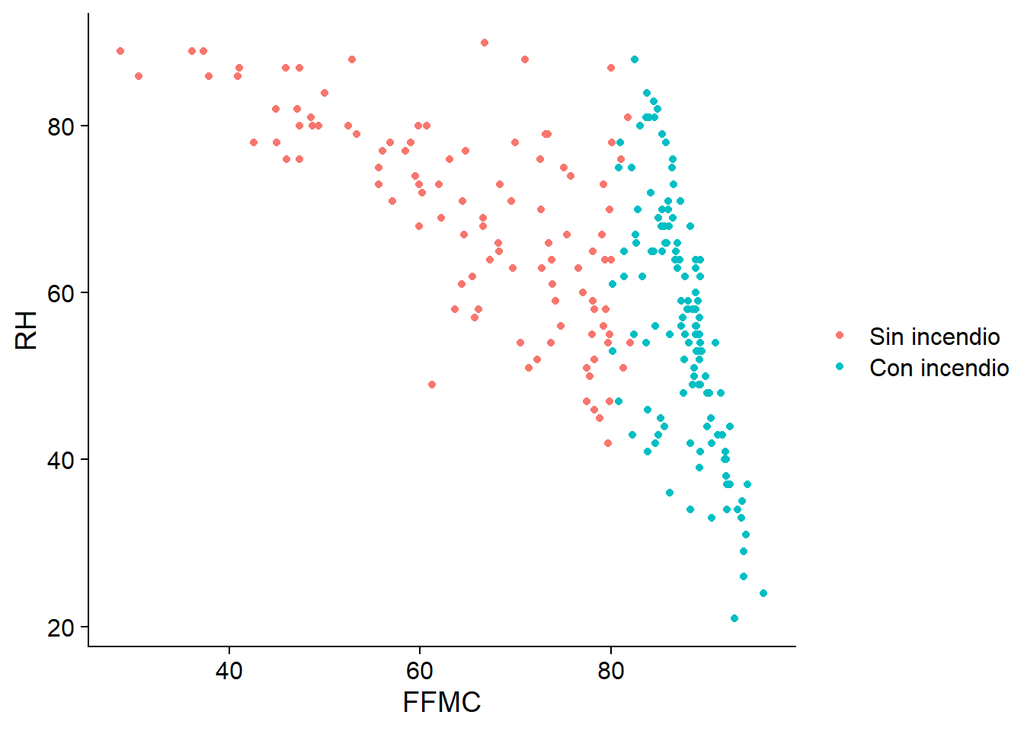

```r
# RH vs. FFMMC
ggplot(incendios, aes(x = FFMC, y = RH, color = Classes)) +
  geom_point() +
  labs(x = "FFMC",
       y = "RH",
       color = "") +
  theme_cowplot()
```

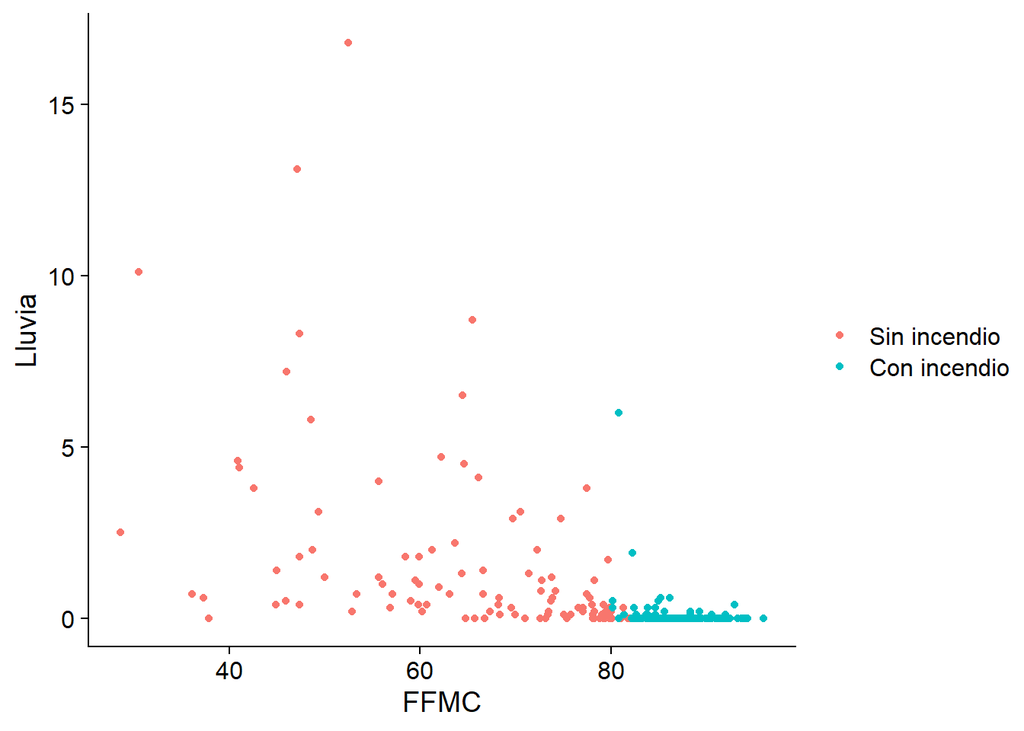

```r
# Lluvia vs. FFMMC
ggplot(incendios, aes(x = FFMC, y = Rain, color = Classes)) +
  geom_point() +
  labs(x = "FFMC",
       y = "Lluvia",
       color = "") +
  theme_cowplot()
```

## ISI y Temperatura vs. RH

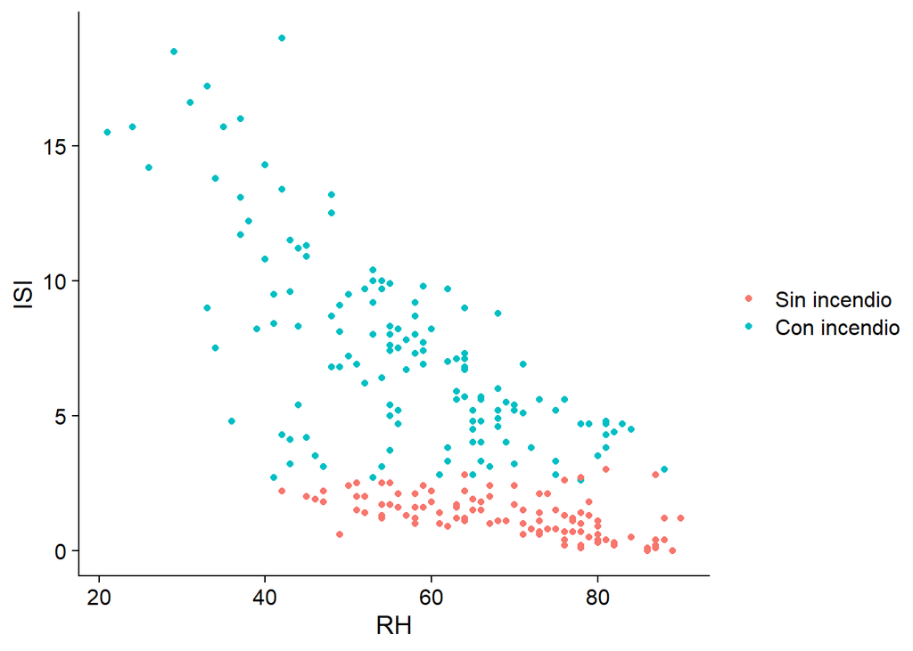

```r
# ISI vs. RH
ggplot(incendios, aes(x = RH, y = ISI, color = Classes)) +
  geom_point() +
  labs(x = "RH",
       y = "ISI",
       color = "") +
  theme_cowplot()
```

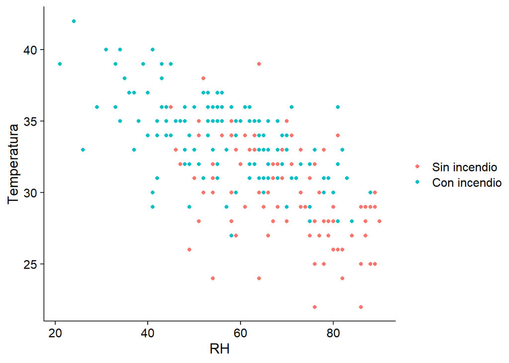

```r
# Temperatura vs. RH
ggplot(incendios, aes(x = RH, y = Temperature, color = Classes)) +
  geom_point() +
  labs(x = "RH",
       y = "Temperatura",
       color = "") +
  theme_cowplot()
```

## Variables vs. FWI

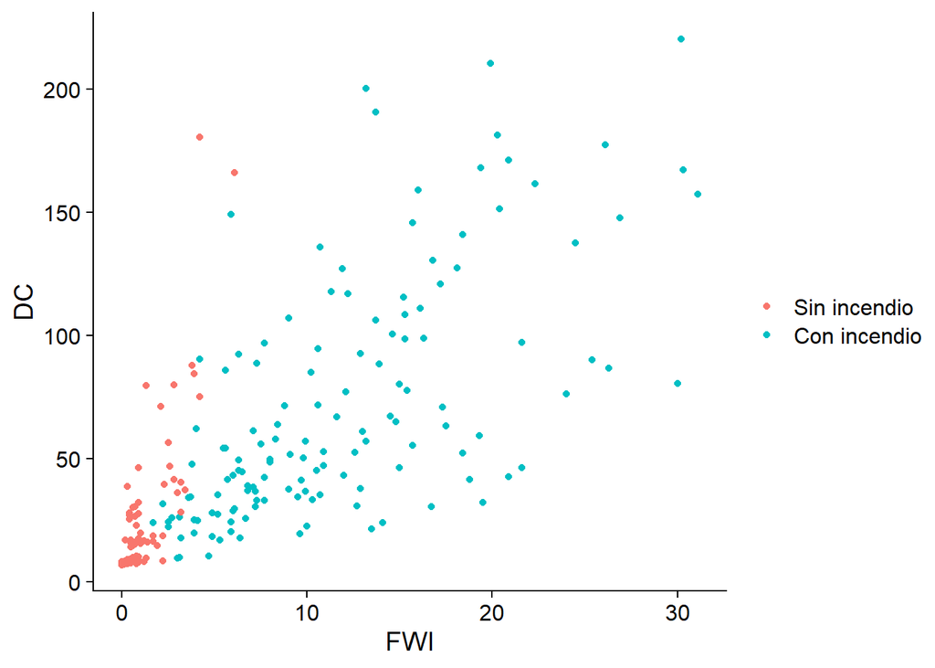

```r
# DC vs. FWI
ggplot(incendios, aes(x = FWI, y = DC, color = Classes)) +
  geom_point() +
  labs(x = "FWI",
       y = "DC",
       color = "") +
  theme_cowplot()
```

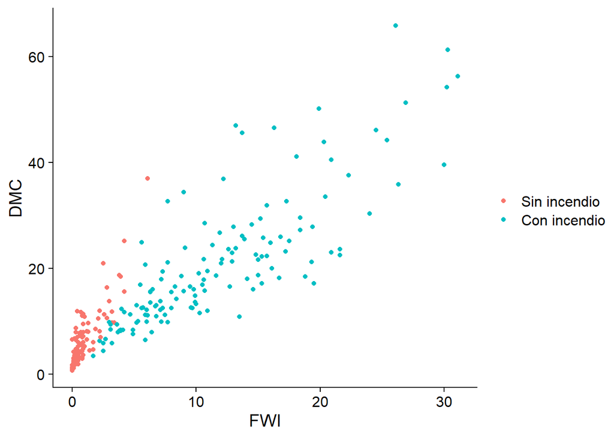

```r
# DMC vs. FWI
ggplot(incendios, aes(x = FWI, y = DMC, color = Classes)) +
  geom_point() +
  labs(x = "FWI",
       y = "DMC",
       color = "") +
  theme_cowplot()
```

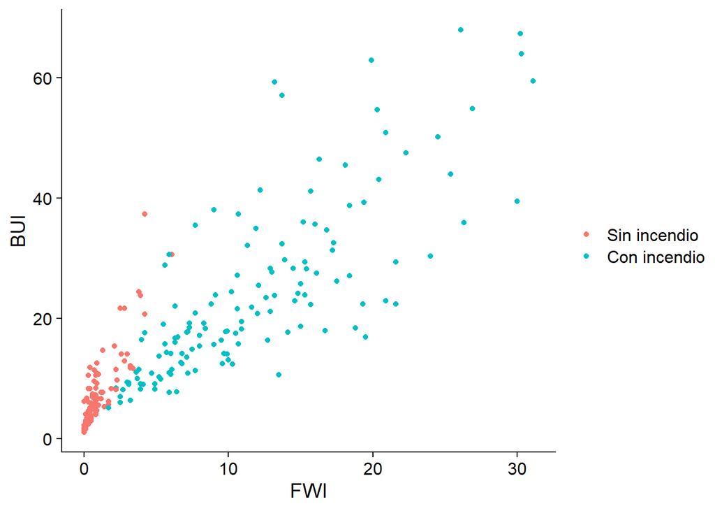

```r
# BUI vs. FWI
ggplot(incendios, aes(x = FWI, y = BUI, color = Classes)) +
  geom_point() +
  labs(x = "FWI",
       y = "BUI",
       color = "") +
  theme_cowplot()
```

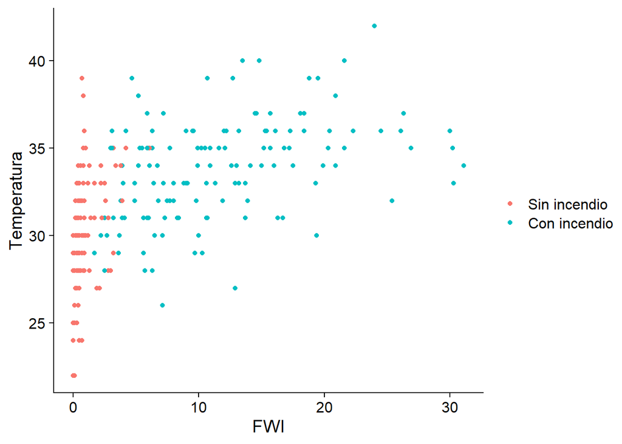

```r
# Temperatura vs. FWI
ggplot(incendios, aes(x = FWI, y = Temperature, color = Classes)) +
  geom_point() +
  labs(x = "FWI",
       y = "Temperatura",
       color = "") +
  theme_cowplot()
```

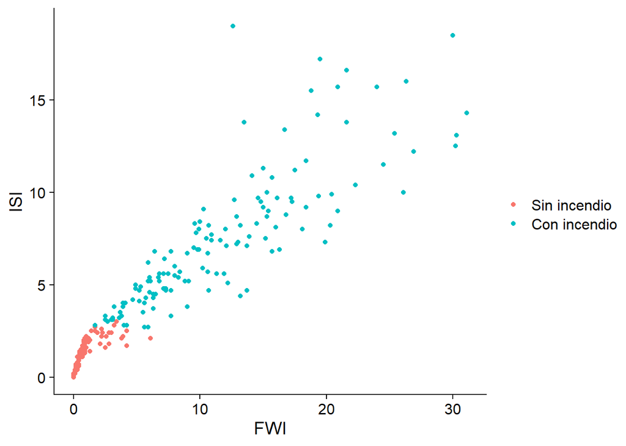

```r
# ISI vs. FWI
ggplot(incendios, aes(x = FWI, y = ISI, color = Classes)) +
  geom_point() +
  labs(x = "FWI",
       y = "ISI",
       color = "") +
  theme_cowplot()
```

## Variables vs. DC

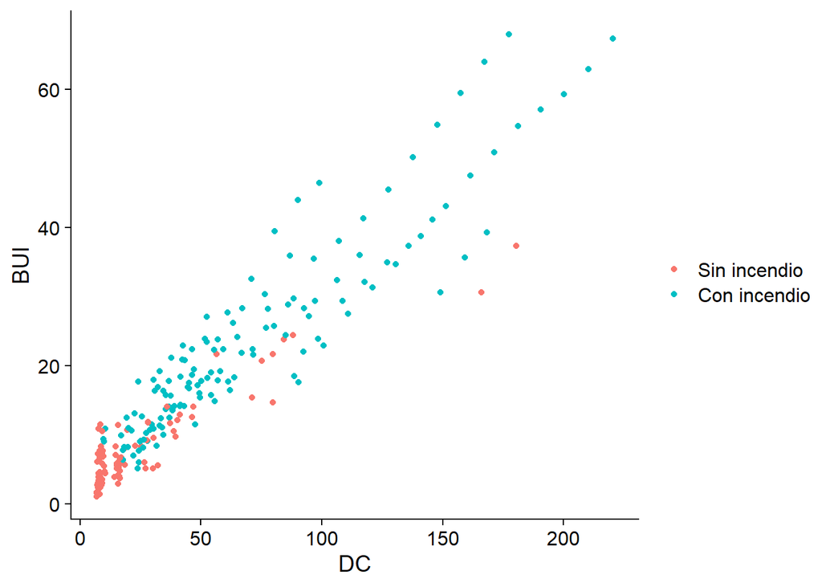

```r
# BUI vs. DC
ggplot(incendios, aes(x = DC, y = BUI, color = Classes)) +
  geom_point() +
  labs(x = "DC",
       y = "BUI",
       color = "") +
  theme_cowplot()
```

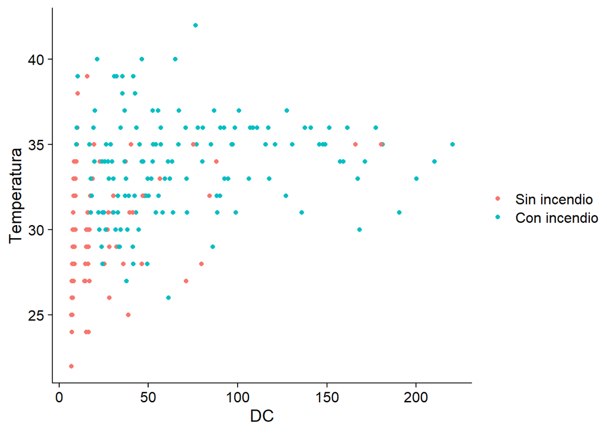

```r
# Temperatura vs. DC
ggplot(incendios, aes(x = DC, y = Temperature, color = Classes)) +
  geom_point() +
  labs(x = "DC",
       y = "Temperatura",
       color = "") +
  theme_cowplot()
```

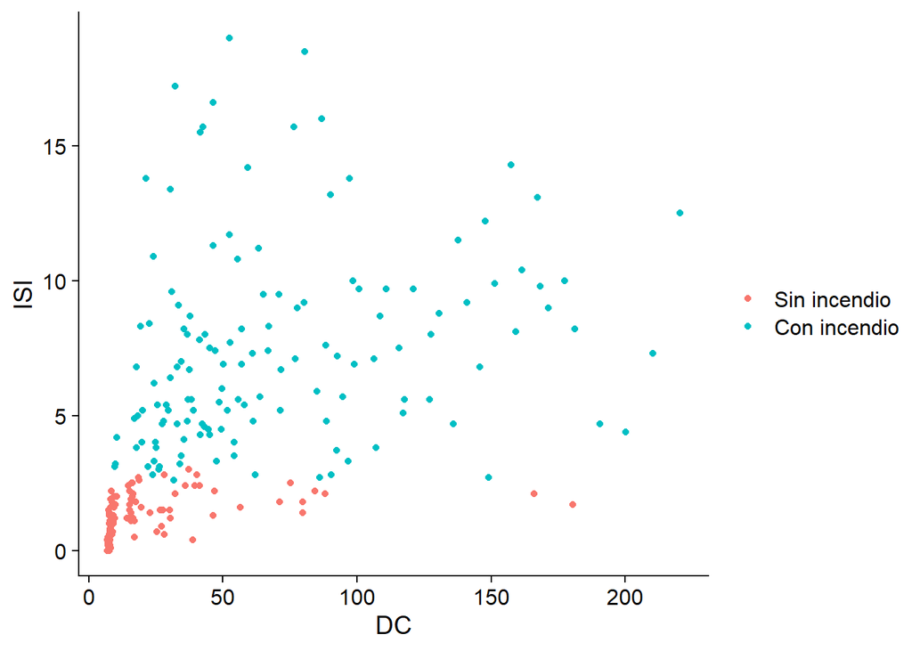

```r
# ISI vs. DC
ggplot(incendios, aes(x = DC, y = ISI, color = Classes)) +
  geom_point() +
  labs(x = "DC",
       y = "ISI",
       color = "") +
  theme_cowplot()
```

## ISI y BUI vs. DMC

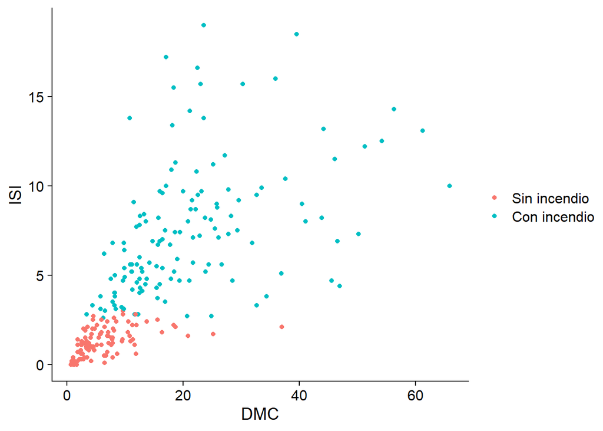

```r
# ISI vs. DMC
ggplot(incendios, aes(x = DMC, y = ISI, color = Classes)) +
  geom_point() +
  labs(x = "DMC",
       y = "ISI",
       color = "") +
  theme_cowplot()
```

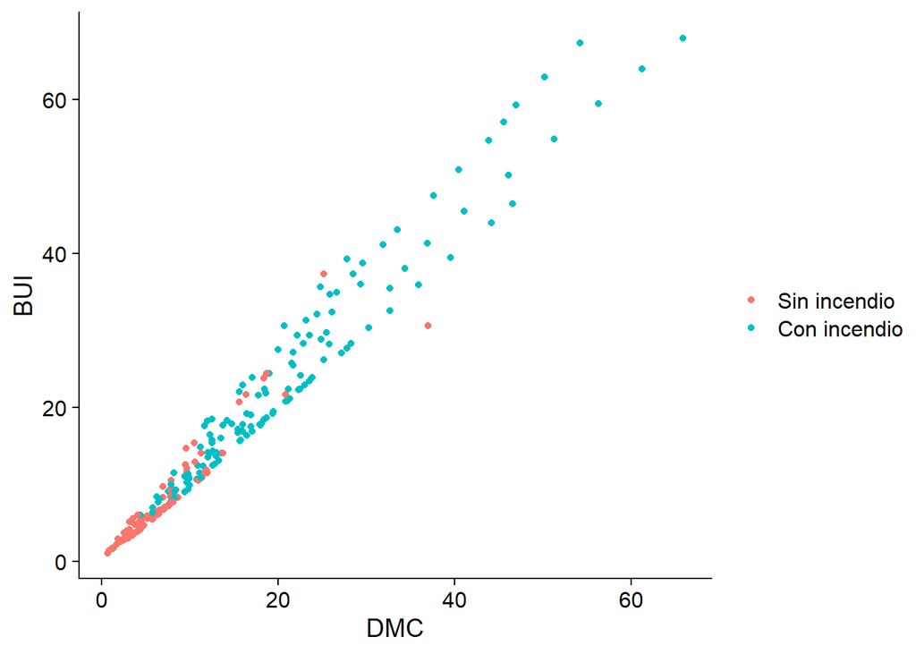

```r
# BUI vs. DMC
ggplot(incendios, aes(x = DMC, y = BUI, color = Classes)) +
  geom_point() +
  labs(x = "DMC",
       y = "BUI",
       color = "") +
  theme_cowplot()
```

# Ajuste de los modelos

## Separación de los datos

Debido a la poca cantidad de observaciones en las bases de datos, se realiza una separación 80/20 en los datos de *training* y *testing* respectivamente.

```r
# Semilla para reproducibilidad
set.seed(0609)

# Se cambia la variable objetivo a numérica, 1 significa que hubo incendio, 0 que no
incendios <- incendios %>% mutate(Classes = ifelse(Classes == "Con incendio", "Incendio", "No.incendio"))

# Se modifica la variable objetivo como factor
incendios$Classes <- factor(incendios$Classes, levels = c("Incendio", "No.incendio"))

# Se agrega una columna de id a la base de datos
incendios$id <- 1:nrow(incendios)

# Se pone de primera la variable de id
incendios <- incendios %>% select(id, colnames(incendios[, 1:ncol(incendios)]))

# Se obtienen los datos de training y testing
data.train <- incendios %>% sample_frac(0.8)
data.test <- anti_join(incendios, data.train, by = "id")
```

## Random forest

Lo primero es la construcción del modelo. Como ya están creados los datos de entrenamiento y de test, se procede con el cálculo del modelo.

```r
modelo <- randomForest(
  Classes ~ . - id,         # No es necesario el id para el modelo
  data = data.train,        # Se le pasan los datos de entrenamiento
  ntree = 100,              # Número de árboles
  importance = TRUE         # Guardar la importancia, para visualización
)
```

El código anterior crea el modelo, para observar los resultados, se imprime de la siguiente forma:

```r
print(modelo)
```

```
##
## Call:
##  randomForest(formula = Classes ~ . - id, data = data.train, ntree = 100,      importance = TRUE)
##                Type of random forest: classification
##                      Number of trees: 100
## No. of variables tried at each split: 3
##
##         OOB estimate of  error rate: 3.09%
## Confusion matrix:
##             Incendio No.incendio class.error
## Incendio         105           3  0.02777778
## No.incendio        3          83  0.03488372
```

De donde se puede observar que los errores de clasificación son muy bajos, el modelo está clasificando los incendios, como incendios, y solo se equivoca en 3. Cuando se tiene un no incencio, este también se equivoca en 3. Lo cual son números muy bajos y lo que sugiere que la clasificación que el modelo está realizando es muy buena. Como el Random Forest utiliza un método bootstrap, el OOB tirá un error bajo de apenas 3%.

El siguiente código realiza la validación cruzada del modelo, es decir, va a dividir el conjunto de datos en subconjuntos, donde algunos se usan de prueba y otros se usan de entrenamiento, pero el modelo iterará, lo que hace que se tengan varias rendimientos, y por último, para conseguir el rendmiento del modelo, se hace un promedio simple de los rendmientos obtenidos.

El número de pliegues, o folds, es la cantidad de subconjuntos en la cual se va a partir el conjunto de datos, para el código se utilió 5, pero es un hiperpárametro, se pueden escoger otros, sin embargo, 5 es lo comúnmente utilizado.

Por otro lado, mtry es otro hiperparámetro que lo que busca es una diferenciación de los árboles, es decir, hacer que los árboles no sean iguales entre sí.

```r
control <- trainControl(
  method = "cv", # Método de Validación Cruzada
  number = 5, # Número de pliegues
  classProbs = TRUE,
  summaryFunction = twoClassSummary,
  verboseIter = FALSE
)

modelo.rf.cv <- train(
  Classes ~ . - id,
  data = data.train,
  method = "rf",
  ntree = 100,
  trControl = control,
  metric = "ROC",
  verbose = TRUE
)

print(modelo.rf.cv)
```

```
## Random Forest
##
## 194 samples
##  14 predictor
##   2 classes: 'Incendio', 'No.incendio'
##
## No pre-processing
## Resampling: Cross-Validated (5 fold)
## Summary of sample sizes: 154, 155, 156, 156, 155
## Resampling results across tuning parameters:
##
##   mtry  ROC        Sens       Spec
##    2    0.9954545  0.9636364  0.9653595
##    7    0.9986631  0.9727273  0.9882353
##   13    0.9983957  0.9727273  0.9882353
##
## ROC was used to select the optimal model using the largest value.
## The final value used for the model was mtry = 7.
```

Según los resultados anteriores, el ROC más grande se obtiene cuando se toma como hiperparámetro la cantidad de variables aleatorias 7, es decir, el mtry = 7, eso significa que en cada árbol se toman como variables aleatorias para clasificar 7 variables (un mtry muy grande provoca que todos los árboles se parezcan entre sí, sobreajustando el modelo. Un mtry muy pequeño no sobreajusta, pero pierde precisión).

Por otro lado se obtiene la cantidad de recall (sensibilidad) del modelo, que indica el grado de aciertos que tuvo el modelo, es decir, cuántos datos de éxito fueron clasificados como éxito. En este caso, de la cantidad de incendios qué proporción fue clasificada como incendio de verdad.

Luego, el valor de Spec es el valor de especificidad, que indica la cantidad de no éxitos clasificados como no éxitos correctamente.

## XGBoost

Luego, nos centramos en el XGBoost. Para este caso usamos la librería [caret](https://topepo.github.io/caret/index.html) para obtener el ajuste. En particular, en el método del [XGBoost](https://www-geeksforgeeks-org.translate.goog/machine-learning/different-results-xgboost-vs-caret-in-r/?_x_tr_sl=en&_x_tr_tl=es&_x_tr_hl=es&_x_tr_pto=tc) que ofrece el paquete.

```r
# Listas para las iteraciones
lista.ll <- list()
lista.int <- list()

# Para ver el número óptimo de iteraciones de validación cruzada, se prueban todos los valores del 1 al 10 y se compara con la pérdida logarítmica
for (i in 2:5) {
  # Ciclo para tomar en cuenta la variabilidad de las observaciones
  for (j in 1:10) {
    # Se define el control de entrenamiento, esto genera los parámetros que se usarán para el modelo.
    ## method: Método de remuestreo, en este caso, de validación cruzada
    ## number: Cantidad de pliegues de la validación cruzada (se puede graficar)
    ## verboseIter: Para imprimir (TRUE) el registro de entrenamiento
    ## classProbs: Define si se calculan las probabilidades para las muestras obtenidas del remuestreo
    ## selectionFunction: Permite definir los parámetros óptimos según una métrica. En este caso, para clasificación binaria
    ## returnResamp: Permite guardar los remuestreos
    ## allowParallel: Permite la paralelización
    control.entrenamiento <-
      trainControl(
        method = "cv",
        number = i,
        verboseIter = FALSE,
        classProbs = TRUE,
        summaryFunction = twoClassSummary
      )

    # Se define el modelo del XGBoost. Internamente tiene una variable desactualizada en caret, por lo que puede tirar un warning
    ## x: Variable objetivo (la que se busca predecir)
    ## data: Datos a utilizar (debe ser DataFrame)
    ## method: Método a utilizar, en este caso, XGBoost
    ## trControl: El objeto con los parámetros óptimos encontrados anteriormente
    ## metric: La métrica a optimizar. En este caso, la curva ROC
    modelo.xgb <- train(
      Classes ~ .,
      data = data.train,
      method = "xgbTree",
      trControl = control.entrenamiento,
      metric = "ROC",
      verbose = FALSE
    )

    # Se calcula la pérdida logarítmica. Primero se predicen las probabilidades con los datos de testing
    prediccion.xgb <-
      predict(modelo.xgb, newdata = data.test, type = "prob")

    # Se obtienen las observaciones que son incendios
    prob.incendio <- prediccion.xgb$Incendio

    # Vector binario para saber si la clase es incendio o no
    obs.incendio <- data.test$Classes == "Incendio"

    # Se corrigen las probabilidades de incendio con un epsilon, por los valores extremos de [0, 1]
    prob.incendio <- pmin(pmax(prob.incendio, 1e-15), 1 - 1e-15)

    # Se guardan las iteraciones con cada número de iteraciones
    lista.int[[j]] <- -mean(obs.incendio * log(prob.incendio) + (1 - obs.incendio) * log(1 - prob.incendio))
  }


  # Pérdida logarítmica
  lista.ll[[(i - 1)]] <- c(i, mean(unlist(lista.int)))
}
```

[output not shown]

[output cut: 20105 more lines]

[output not shown]

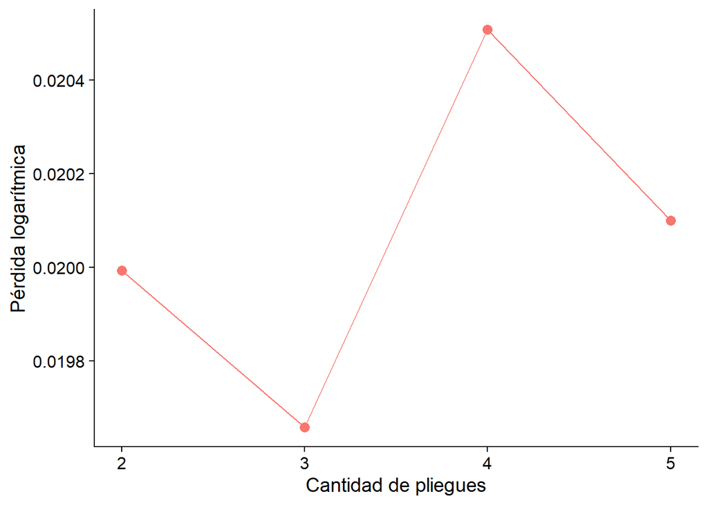

```r
# Se pasan los resultados a un DataFrame
df.logloss <- as.data.frame(do.call(rbind, lista.ll))

# Se cambian los nombres
colnames(df.logloss) <- c("iter", "logl")

# Se grafica cada resultado obtenido
ggplot(df.logloss, aes(x = iter, y = logl)) +
  geom_line(color = "#F8766D") +
  geom_point(color = "#F8766D",
             size = 3,
             shape = 16) +
  labs(x = "Cantidad de pliegues",
       y = "Pérdida logarítmica") +
  theme_cowplot()
```

Debido a que una pérdida logarítmica menor implica un mejor modelo, se seleccionó el modelo de validación cruzada con 3 iteraciones.

Ahora, se crea un modelo completo, para ver la importancia que tienen todas las variables.

```r
# Se define el control de entrenamiento, esto genera los parámetros que se usarán para el modelo.
    ## method: Método de remuestreo, en este caso, de validación cruzada
    ## number: Cantidad de pliegues de la validación cruzada (se puede graficar)
    ## verboseIter: Para imprimir (TRUE) el registro de entrenamiento
    ## classProbs: Define si se calculan las probabilidades para las muestras obtenidas del remuestreo
    ## selectionFunction: Permite definir los parámetros óptimos según una métrica. En este caso, para clasificación binaria
    ## returnResamp: Permite guardar los remuestreos
    ## allowParallel: Permite la paralelización
    control.entrenamiento <-
      trainControl(
        method = "cv",
        number = 3,
        verboseIter = FALSE,
        classProbs = TRUE,
        summaryFunction = twoClassSummary
      )

    # Se define el modelo del XGBoost. Internamente tiene una variable desactualizada en caret, por lo que puede tirar un warning
    ## En el primer espacio se elige la variable objetivo y las variables a usar
    ## x: Variable objetivo (la que se busca predecir)
    ## data: Datos a utilizar (debe ser DataFrame)
    ## method: Método a utilizar, en este caso, XGBoost
    ## trControl: El objeto con los parámetros óptimos encontrados anteriormente
    ## metric: La métrica a optimizar. En este caso, la curva ROC
    modelo.xgb <- train(
      Classes ~ .,
      data = data.train,
      method = "xgbTree",
      trControl = control.entrenamiento,
      metric = "ROC",
      verbose = FALSE
    )
```

[output not shown]

[output cut: 377 more lines]

[output not shown]

```r
modelo.xgb
```

```
## eXtreme Gradient Boosting
##
## 194 samples
##  14 predictor
##   2 classes: 'Incendio', 'No.incendio'
##
## No pre-processing
## Resampling: Cross-Validated (3 fold)
## Summary of sample sizes: 129, 130, 129
## Resampling results across tuning parameters:
##
##   eta  max_depth  colsample_bytree  subsample  nrounds  ROC        Sens
##   0.3  1          0.6               0.50        50      0.9987229  0.9629630
##   0.3  1          0.6               0.50       100      0.9984036  0.9629630
##   0.3  1          0.6               0.50       150      0.9984036  0.9629630
##   0.3  1          0.6               0.75        50      0.9988654  0.9722222
##   0.3  1          0.6               0.75       100      0.9988654  0.9722222
##   0.3  1          0.6               0.75       150      0.9988654  0.9722222
##   0.3  1          0.6               1.00        50      0.9980501  0.9629630
##   0.3  1          0.6               1.00       100      0.9980501  0.9722222
##   0.3  1          0.6               1.00       150      0.9980501  0.9722222
##   0.3  1          0.8               0.50        50      0.9985575  0.9722222
##   0.3  1          0.8               0.50       100      0.9985575  0.9629630
##   0.3  1          0.8               0.50       150      0.9985575  0.9629630
##   0.3  1          0.8               0.75        50      0.9978847  0.9629630
##   0.3  1          0.8               0.75       100      0.9978847  0.9629630
##   0.3  1          0.8               0.75       150      0.9978847  0.9629630
##   0.3  1          0.8               1.00        50      0.9929244  0.9629630
##   0.3  1          0.8               1.00       100      0.9929244  0.9629630
##   0.3  1          0.8               1.00       150      0.9929244  0.9629630
##   0.3  2          0.6               0.50        50      0.9948971  0.9722222
##   0.3  2          0.6               0.50       100      0.9948971  0.9722222
##   0.3  2          0.6               0.50       150      0.9948971  0.9722222
##   0.3  2          0.6               0.75        50      0.9982268  0.9722222
##   0.3  2          0.6               0.75       100      0.9982268  0.9629630
##   0.3  2          0.6               0.75       150      0.9982268  0.9629630
##   0.3  2          0.6               1.00        50      0.9980501  0.9722222
##   0.3  2          0.6               1.00       100      0.9980501  0.9722222
##   0.3  2          0.6               1.00       150      0.9980501  0.9722222
##   0.3  2          0.8               0.50        50      0.9983808  0.9537037
```

[output cut: 182 more lines]

```
##   0.9642857
##   0.9408867
##   0.9408867
##   0.9408867
##   0.9642857
##   0.9642857
##   0.9642857
##
## Tuning parameter 'gamma' was held constant at a value of 0
## Tuning
##  parameter 'min_child_weight' was held constant at a value of 1
## ROC was used to select the optimal model using the largest value.
## The final values used for the model were nrounds = 100, max_depth = 3, eta
##  = 0.3, gamma = 0, colsample_bytree = 0.6, min_child_weight = 1 and subsample
##  = 0.5.
```

En este caso, se pueden ver los parámetros óptimos del modelo, en donde: - nrounds: Es la cantidad de iteraciones (o árboles, en este caso) óptima. - max_depth: Es la complejidad (o profundidad del árbol) máxima. - eta (learning rate): Es un parámetro que se usa para ajustar el modelo, este mejora la presición del algoritmo. En concreto, este indica la resistencia del modelo al sobreajuste. (https://primo-tc-na01.hosted.exlibrisgroup.com/primo-explore/fulldisplay?docid=TN_cdi_proquest_journals_2608081906&context=PC&vid=SIBDI&lang=es_CR&search_scope=sibdiucr_completo&adaptor=primo_central_multiple_fe&tab=sibdiucr_tab&query=any,contains,eta%20xgboost&offset=0) - gamma (min split loss): Es un parámetro que indica el aumento mínimo en la función objetivo (el ROC en este caso), para que el árbol se divida (https://xgboost.readthedocs.io/en/stable/parameter.html). Al ser 0, el algoritmo no es muy conservador. Además, este tiene un peso muy significativo en la predicción final del XGBoost (https://primo-tc-na01.hosted.exlibrisgroup.com/primo-explore/fulldisplay?docid=TN_cdi_acm_books_10_1145_3357254_3357290_brief&context=PC&vid=SIBDI&lang=es_CR&search_scope=sibdiucr_completo&adaptor=primo_central_multiple_fe&tab=sibdiucr_tab&query=any,contains,gamma%20xgboost&offset=0)

# Resultados

## Random forest

Se presenta ahora el valor de la pérdida logarítimica:

```r
probabilidades <- predict(modelo.rf.cv, newdata = data.test, type = "prob")

prob.pos <- probabilidades[, "Incendio"]

y.true <- ifelse(data.test$Classes == "Incendio", 1, 0)

epsilon <- 1e-15
prob.pos <- pmin(pmax(prob.pos, epsilon), 1 - epsilon)

log.loss <- -mean(y.true * log(prob.pos) + (1 - y.true) * log(1 - prob.pos))
print(log.loss)
```

```
## [1] 0.01940836
```

Un valor cercano a 0 de la pérdida logarítmica implica que el modelo está realizando una buena clasificación.

Se procede con un gráfico de la importancia de las variables a la hora de predecir.

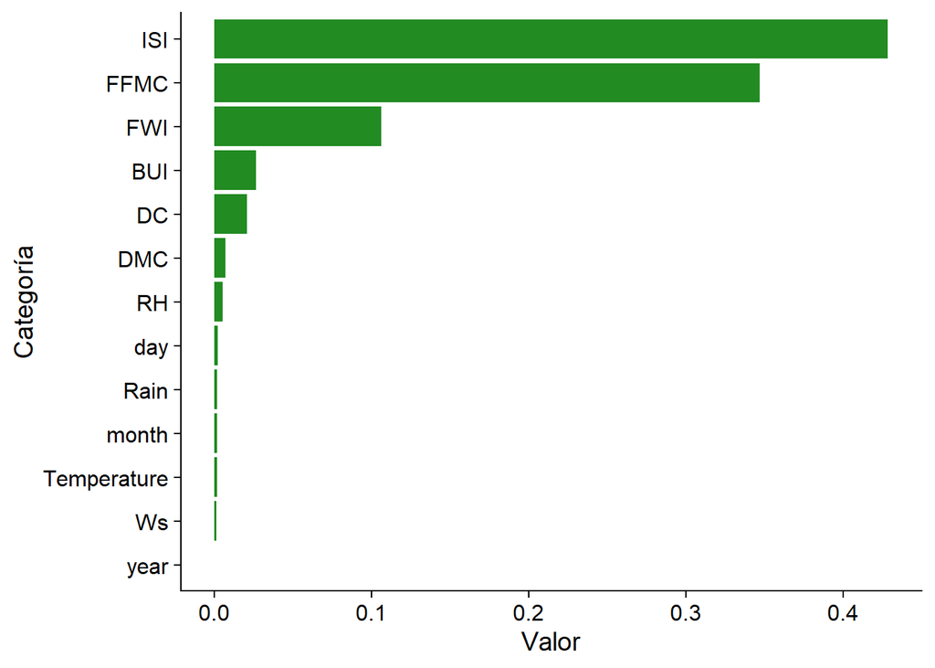

```r
# Se guarda la importancia de las variables
importancia <- varImp(modelo.rf.cv, scale = FALSE)

# Se deja solo el DataFrame
importancia <- data.frame(variable = rownames(importancia$importance),
                          promedio_importancia = importancia$importance[, 1])

# Se grafica lo anterior
ggplot(importancia, aes(x = reorder(variable, promedio_importancia), y = promedio_importancia / 100)) +
  geom_bar(stat = "identity", fill = "forestgreen") +
  coord_flip() +
  labs(x = "Categor\u00eda", y = "Valor") +
  theme_cowplot()
```

El siguiente código tiene la intención de evaluar las bondades del modelo, es decir, dar estadísticos para evaluar su precisión y capacidad de predicción/clasificación.

```r
predicciones <- predict(modelo.rf.cv, newdata = data.test)

predicciones <- factor(predicciones, levels = c("No.incendio", "Incendio"))
reales <- factor(data.test$Classes, levels = c("No.incendio", "Incendio"))

# Matriz de confusión
mat.conf <- confusionMatrix(predicciones, reales, positive = "Incendio")

mat.conf
```

```
## Confusion Matrix and Statistics
##
##              Reference
## Prediction    No.incendio Incendio
##   No.incendio          20        0
##   Incendio              0       29
##
##                Accuracy : 1
##                  95% CI : (0.9275, 1)
##     No Information Rate : 0.5918
##     P-Value [Acc > NIR] : 6.885e-12
##
##                   Kappa : 1
##
##  Mcnemar's Test P-Value : NA
##
##             Sensitivity : 1.0000
##             Specificity : 1.0000
##          Pos Pred Value : 1.0000
##          Neg Pred Value : 1.0000
##              Prevalence : 0.5918
##          Detection Rate : 0.5918
##    Detection Prevalence : 0.5918
##       Balanced Accuracy : 1.0000
##
##        'Positive' Class : Incendio
##
```

Analizando los resultados de este código, se tiene que:

- Accuracy es de 1, lo que significa que el modelo predice muy bien.
- Lo siguiente es el intervalo de confianza donde se encuentran el 95% de los datos.
- No Information Rate (NIR) es una tasa que significa que si el modelo siempre predijera incendios, entonces el modelo acertaría el 59% de las veces, es decir, ligeramente mejor que al azar. Lo que significa que nuestro clasificador está bien, pues es superior a este valor.
- El p-value es simplemente una prueba de hipótesis que se realiza. La hipótesis nula del modelo dice que el modelo de clasificación no es mejor que el modelo que siempre clasifica incendio. En este caso, el valor es muy significativo, por lo que hay evidencia estadística fuerte para rechazar la hipótesis nula.
- El índice kappa está dando 1, lo que significa que la suerte no está influyendo en el resultado. Es decir, entre más bajo es el índice kappa, significa que por azar, se está clasificando de manera correcta. Entre más alto significa que el modelo está clasificando correctamente porque aprendió.

Se grafica la matriz de confusión para su visualización.

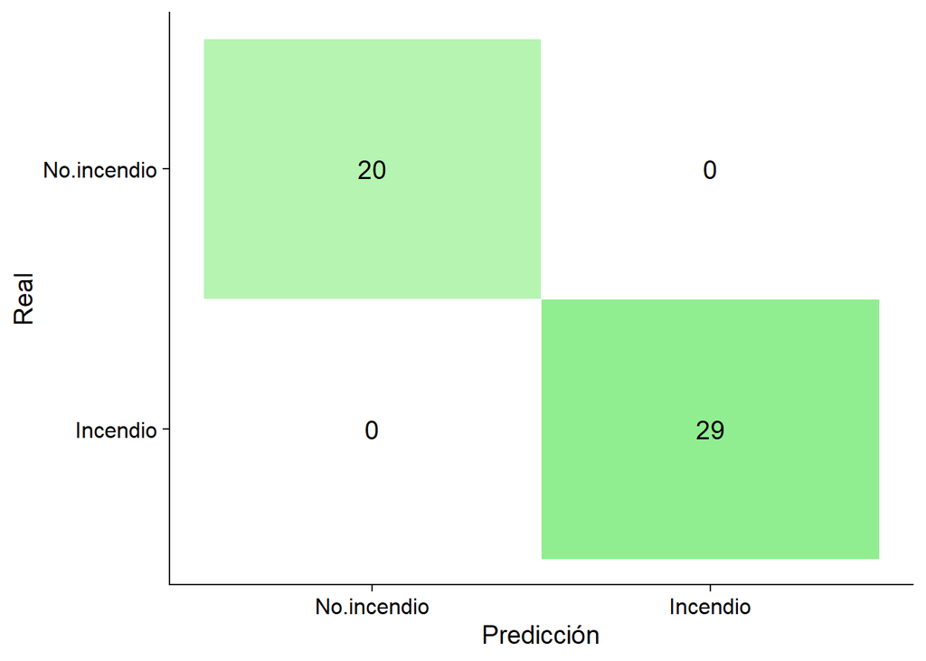

```r
mat.conf.df <- as.data.frame(mat.conf$table)

mat.conf.df$Reference <- factor(mat.conf.df$Reference,
                                levels = c("Incendio", "No.incendio"))

mat.conf.df$Prediction <- factor(mat.conf.df$Prediction,
                                 levels = c("No.incendio", "Incendio"))

ggplot(mat.conf.df, aes(x = Prediction, y = Reference, fill = Freq)) +
  geom_tile(color = "white") +
  geom_text(aes(label = Freq), size = 5) +
  scale_fill_gradient(low = "white", high = "lightgreen") +
  labs(x = "Predicción", y = "Real") +
  theme_cowplot() +
  theme(legend.position = "none")
```

Se procede con la curva ROC, la cual tiene la intención de presentar de manera gráfica la capacidad del modelo para clasificar.

```r
df.pred <- data.frame(
  truth = data.test$Classes,
  prediction = predicciones
)

roc.rf <- roc(
  response = data.test$Classes,
  predictor = ifelse(df.pred$prediction == "Incendio", 1, 0),
  levels = c("No.incendio", "Incendio")
)
```

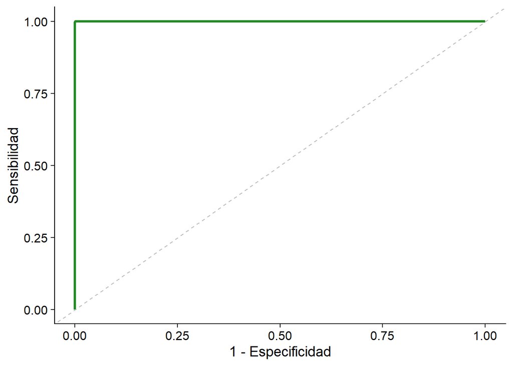

```r
# Se obtiene un dataframe de los parámetros para construir la curva ROC
roc.df.rf <- data.frame(
  specificity = rev(roc.rf$specificities),
  sensitivity = rev(roc.rf$sensitivities)
)

# Gráfico de la curva ROC
ggplot(roc.df.rf, aes(x = 1 - specificity, y = sensitivity)) +
  geom_line(color = "forestgreen", linewidth = 1.2) +
  geom_abline(linetype = "dashed", color = "gray") +
  labs(
    x = "1 - Especificidad",
    y = "Sensibilidad"
  ) +
  theme_cowplot()
```

## XGBoost

En este punto, se muestran algunas de las métricas del modelo XGBoost.

A continuación se muestra la [importancia](https://topepo.github.io/caret/variable-importance.html#an-example-2) de cada una de las variables en el modelo, esto en escala del 0 al 1.

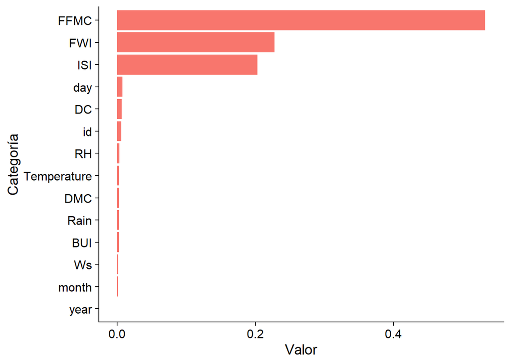

```r
# Se guarda la importancia de las variables
importancia <- varImp(modelo.xgb, scale = FALSE)

# Se deja solo el dataframe
importancia <- data.frame(variable = rownames(importancia[[1]]),
                          promedio_importancia = importancia[[1]][, 1])

# Se grafica lo anterior
ggplot(importancia, aes(x = reorder(variable, promedio_importancia), y = promedio_importancia)) +
  geom_bar(stat = "identity", fill = "#F8766D") +
  coord_flip() +
  labs(x = "Categoría", y = "Valor") +
  theme_cowplot()
```

Se procede con la curva ROC, que fue la métrica que se maximizó en este caso.

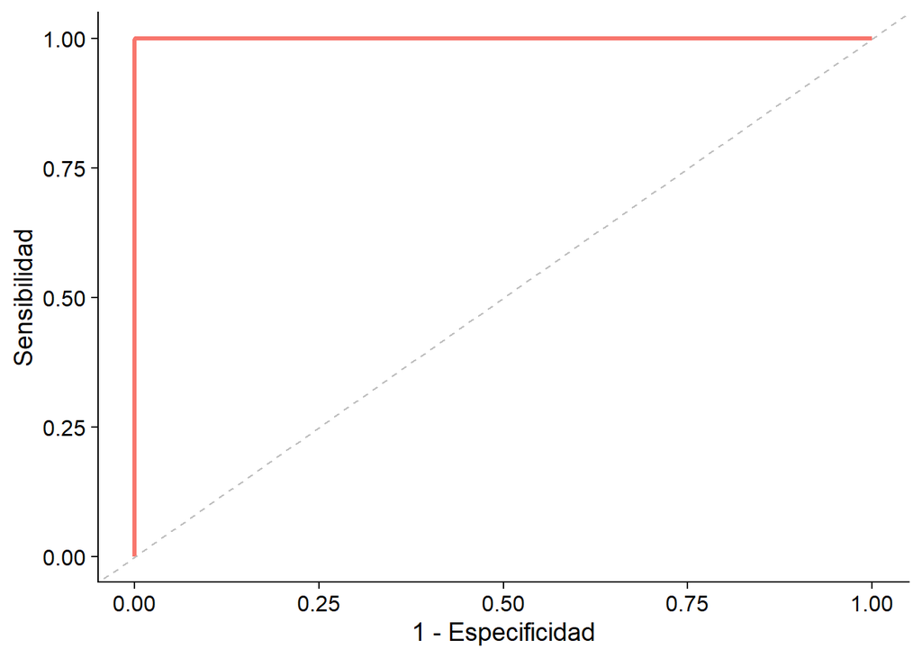

```r
# Se predicen las probabilidades con los datos de testing
prediccion.xgb <-
  predict(modelo.xgb, newdata = data.test, type = "prob")

# Curva ROC
roc.xgb <-
  roc(
    response = data.test$Classes,
    predictor = prediccion.xgb$Incendio,
    levels = c("Incendio", "No.incendio"),
    direction = ">"
  )

# Se obtiene un dataframe de los parámetros para construir la curva ROC
roc.df.xgb <- data.frame(
  specificity = rev(roc.xgb$specificities),
  sensitivity = rev(roc.xgb$sensitivities)
)

# Gráfico de la curva ROC
ggplot(roc.df.xgb, aes(x = 1 - specificity, y = sensitivity)) +
  geom_line(color = "#F8766D", linewidth = 1.2) +
  geom_abline(linetype = "dashed", color = "gray") +
  labs(
    x = "1 - Especificidad",
    y = "Sensibilidad"
  ) +
  theme_cowplot()
```

```r
# Valor del AUC
auc(roc.xgb)
```

```
## Area under the curve: 1
```

```r
# Valor del índice de Gini
cat("Índice de Gini: ", 2 * auc(roc.xgb) - 1)
```

```
## Índice de Gini:  1
```

Se continúa con la matriz de confusión.

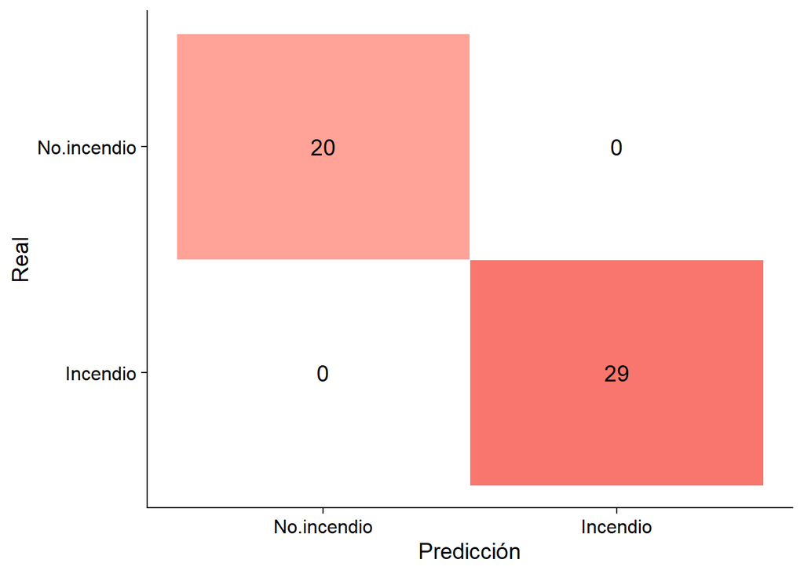

```r
# Cambiamos el tipo de predicción
prediccion.xgb <- predict(modelo.xgb, newdata = data.test)

# Se extrae la matriz de confusión
mat.conf.xgb <-
  confusionMatrix(prediccion.xgb, data.test$Classes, positive = "Incendio")

# Se pasa a data.frame
mat.conf.xgb <- as.data.frame(mat.conf.xgb$table)

# Se cambia a factor
mat.conf.xgb$Reference <-
  factor(mat.conf.xgb$Reference, levels = levels(data.test$Classes))
mat.conf.xgb$Prediction <-
  factor(mat.conf.xgb$Prediction, levels = c("No.incendio", "Incendio"))

# Se grafica lo anterior
ggplot(mat.conf.xgb, aes(x = Prediction, y = Reference, fill = Freq)) +
  geom_tile(color = "white") +
  geom_text(aes(label = Freq), size = 5, color = "black") +
  scale_fill_gradient(low = "white", high = "#F8766D") +
  labs(x = "Predicción",
       y = "Real") +
  theme_cowplot() +
  theme(legend.position = "none")
```

Se procede con las métricas derivadas de la matriz de confusión.

```r
# Se recalcula la matriz de confusión, para tenerla en el formato correspondiente
mat.conf.xgb <-
  confusionMatrix(prediccion.xgb, data.test$Classes, positive = "Incendio")

# Métricas correspondientes
cat("La acurracy (exactitud) es: ", mat.conf.xgb$overall["Accuracy"], "\n")
```

```
## La acurracy (exactitud) es:  1
```

```r
cat("La sensibilidad es: ", mat.conf.xgb$byClass["Sensitivity"], "\n")
```

```
## La sensibilidad es:  1
```

```r
cat("La especificidad es: ", mat.conf.xgb$byClass["Specificity"], "\n")
```

```
## La especificidad es:  1
```

```r
cat("La precisión es: ", mat.conf.xgb$byClass["Precision"])
```

```
## La precisión es:  1
```

Finalmente, se tiene la pérdida logarítmica o log-loss.

```r
# Se predicen las probabilidades con los datos de testing
prediccion.xgb <-
  predict(modelo.xgb, newdata = data.test, type = "prob")

# Se obtienen las observaciones que son incendios
prob.incendio <- prediccion.xgb$Incendio

# Vector binario para saber si la clase es incendio o no
obs.incendio <- data.test$Classes == "Incendio"

# Se corrigen las probabilidades de incendio con un epsilon, por los valores extremos de [0, 1]
prob.incendio <- pmin(pmax(prob.incendio, 1e-15), 1 - 1e-15)

# Pérdida logarítmica
log.loss <- -mean(obs.incendio * log(prob.incendio) + (1 - obs.incendio) * log(1 - prob.incendio))
cat("La pérdida logarítmica (log-loss) es: ", log.loss)
```

```
## La pérdida logarítmica (log-loss) es:  0.01671777
```